# Assignment 02 - Data Viz and Wrangling

Published

February 13, 2026

## Due Date

This assignment is due by 11:59pm Eastern Time, February 27th, 2026, submitted on [Github issues](https://github.com/dmcable/BIOSTAT620W26/issues/5).

For this assignment, we will be analyzing data from USC’s Children’s Health Study. The learning objectives are to conduct data wrangling and visualize the data with key questions in mind. For each problem, try to show your work by displaing main variable outputs (e.g. `print(head(my_dataframe))`) as you progress.

## Data Wrangling

You will need to download two CHS datasets. The [individual](https://raw.githubusercontent.com/dmcable/BIOSTAT620W26/main/data/chs/chs_individual.csv) and [regional](https://raw.githubusercontent.com/dmcable/BIOSTAT620W26/main/data/chs/chs_regional.csv) CHS datasets in `chs`. The individual data includes personal and health characteristics of children in 12 communities across Southern California. The regional data include air quality measurements at the community level. You will need to do the following:

### 1. (20 points)

Once downloaded, you can merge these datasets using the `location` variable. After merging the data, make sure you don’t have any duplicates by counting the number of rows. Make sure it matches.

In the case of missing values, impute data using the average amongst individuals with the same values for the “male” and “hispanic” variables. For categorical variables, take the mode. If you are interested (and feel adventurous) in the theme of Data Imputation, take a look at this paper on “Multiple Imputation” using the Amelia R package [here](https://gking.harvard.edu/files/gking/files/amelia_jss.pdf).

```r
library(tidyverse)
# --- 1. Load the Data ---
url_ind <- "https://raw.githubusercontent.com/dmcable/BIOSTAT620W26/main/data/chs/chs_individual.csv"
url_reg <- "https://raw.githubusercontent.com/dmcable/BIOSTAT620W26/main/data/chs/chs_regional.csv"

chs_ind <- read_csv(url_ind)
chs_reg <- read_csv(url_reg)
# --- 2. Merge the Datasets ---
# Merge the data
chs_merged <- merge(chs_ind, chs_reg, by = "townname", all.x = TRUE)

# --- 3. Check for Duplicates ---
nrow(chs_merged)
```

```
[1] 1200
```

```r
head(chs_merged)
```

```
  townname sid male race hispanic    agepft height weight      bmi asthma
1   Alpine 841    1    W        1 10.548939    150     78 15.75758      0
2   Alpine 835    0    W        0 10.099932    143     69 15.33749      0
3   Alpine 838    0    O        1  9.486653    133     62 15.93183      0
4   Alpine 840    0    W        0  9.965777    146     78 16.63283      0
5   Alpine 865    0    W        0 10.039699    162    140 24.24797      1
6   Alpine 867    0    W        1  9.957563    141     94 21.49151      0
  active_asthma father_asthma mother_asthma wheeze hayfever allergy educ_parent
1             0             0             0      0        0       0           5
2             0             0             0      0        0       1           3
3             0             0             0      0        0       0           4
4             0             0             0      0        0       0          NA
5             1             0             0      1        0       1           3
6             0            NA             0      0        0       0           5
  smoke pets gasstove      fev      fvc     mmef pm25_mass pm25_so4 pm25_no3
```

[output cut: 27 more lines]

```r
# --- 4. Impute Missing Values ---
get_mode <- function(v) {
  uniqv <- unique(na.omit(v))
  uniqv[which.max(tabulate(match(v, uniqv)))]
}

chs_imputed <- chs_merged %>%
  group_by(male, hispanic) %>%
  mutate(
    # For numeric columns: replace NA with the mean of the group
    across(where(is.numeric), ~ ifelse(is.na(.), mean(., na.rm = TRUE), .)),

    # For categorical (character/factor) columns: replace NA with the mode of the group
    across(where(is.character), ~ ifelse(is.na(.), get_mode(.), .))
  ) %>%
  ungroup()

# Check if there are any NAs left
total_na <- sum(is.na(chs_imputed))

# Display the final imputed dataframe
print(head(chs_imputed))
```

```
# A tibble: 6 × 49
  townname   sid  male race  hispanic agepft height weight   bmi asthma
  <chr>    <dbl> <dbl> <chr>    <dbl>  <dbl>  <dbl>  <dbl> <dbl>  <dbl>
1 Alpine     841     1 W            1  10.5     150     78  15.8      0
2 Alpine     835     0 W            0  10.1     143     69  15.3      0
3 Alpine     838     0 O            1   9.49    133     62  15.9      0
4 Alpine     840     0 W            0   9.97    146     78  16.6      0
5 Alpine     865     0 W            0  10.0     162    140  24.2      1
6 Alpine     867     0 W            1   9.96    141     94  21.5      0
# ℹ 39 more variables: active_asthma <dbl>, father_asthma <dbl>,
#   mother_asthma <dbl>, wheeze <dbl>, hayfever <dbl>, allergy <dbl>,
#   educ_parent <dbl>, smoke <dbl>, pets <dbl>, gasstove <dbl>, fev <dbl>,
#   fvc <dbl>, mmef <dbl>, pm25_mass <dbl>, pm25_so4 <dbl>, pm25_no3 <dbl>,
#   pm25_nh4 <dbl>, pm25_oc <dbl>, pm25_ec <dbl>, pm25_om <dbl>, pm10_oc <dbl>,
#   pm10_ec <dbl>, pm10_tc <dbl>, formic <dbl>, acetic <dbl>, hcl <dbl>,
#   hno3 <dbl>, o3_max <dbl>, o3106 <dbl>, o3_24 <dbl>, no2 <dbl>, …
```

### 2. (10 points)

Create a new categorical variable named “obesity_level” using the BMI measurement (underweight BMI<14; normal BMI 14-22; overweight BMI 22-24; obese BMI>24). To make sure the variable is rightly coded, create a summary table that contains the minimum BMI, maximum BMI, and the total number of observations per category.

```r
# --- 1. Create the 'obesity_level' variable ---
chs_imputed <- chs_imputed %>%
  mutate(obesity_level = case_when(
    bmi < 14 ~ "Underweight",
    bmi >= 14 & bmi <= 22 ~ "Normal",
    bmi > 22 & bmi <= 24 ~ "Overweight",
    bmi > 24 ~ "Obese"
  ))

chs_imputed$obesity_level <- factor(chs_imputed$obesity_level,
                                    levels = c("Underweight", "Normal", "Overweight", "Obese"))

# --- 2. Create the Summary Table ---
summary_table <- chs_imputed %>%
  group_by(obesity_level) %>%
  summarise(
    Min_BMI = min(bmi, na.rm = TRUE),
    Max_BMI = max(bmi, na.rm = TRUE),
    Total_Observations = n()
  )

print(summary_table)
```

```
# A tibble: 4 × 4
  obesity_level Min_BMI Max_BMI Total_Observations
  <fct>           <dbl>   <dbl>              <int>
1 Underweight      11.3    14.0                 35
2 Normal           14.0    22.0                975
3 Overweight       22.0    24.0                 87
4 Obese            24.0    41.3                103
```

### 3. (10 points)

Create another categorical variable named “smoke_gas_exposure” that summarizes “Second Hand Smoke” and “Gas Stove.” The variable should have four categories in total.

```r
# --- 1. Create the 'smoke_gas_exposure' variable ---
chs_imputed <- chs_imputed %>%
  mutate(smoke_gas_exposure = case_when(
    smoke == 0 & gasstove == 0 ~ "None",
    smoke == 1 & gasstove == 0 ~ "Smoke Only",
    smoke == 0 & gasstove == 1 ~ "Gas Stove Only",
    smoke == 1 & gasstove == 1 ~ "Both"
  ))

# --- 2. Verify the new variable ---
table(chs_imputed$smoke_gas_exposure)
```

```
          Both Gas Stove Only           None     Smoke Only
           151            739            214             36
```

### 4. (10 points)

Create four summary tables showing the average (or proportion, if binary) and sd of “Forced expiratory volume in 1 second (ml)” (an asthma indicator) by town, sex, obesity level, and “smoke_gas_exposure.” Comment on your findings.

```r
# 4a. Summary by Town
summary_town <- chs_imputed %>%
  group_by(townname) %>%
  summarise(
    Mean_FEV = mean(fev, na.rm = TRUE),
    SD_FEV = sd(fev, na.rm = TRUE),
    Count = n()
  )
print(summary_town)
```

```
# A tibble: 12 × 4
   townname      Mean_FEV SD_FEV Count
   <chr>            <dbl>  <dbl> <int>
 1 Alpine           2087.   291.   100
 2 Atascadero       2076.   324.   100
 3 Lake Elsinore    2039.   304.   100
 4 Lake Gregory     2085.   320.   100
 5 Lancaster        2003.   317.   100
 6 Lompoc           2034.   351.   100
 7 Long Beach       1986.   319.   100
 8 Mira Loma        1985.   325.   100
 9 Riverside        1990.   278.   100
10 San Dimas        2027.   319.   100
11 Santa Maria      2026.   312.   100
12 Upland           2024.   343.   100
```

```r
# 4b. Summary by Sex
summary_sex <- chs_imputed %>%
  mutate(sex_label = ifelse(male == 1, "Male", "Female")) %>%
  group_by(sex_label) %>%
  summarise(
    Mean_FEV = mean(fev, na.rm = TRUE),
    SD_FEV = sd(fev, na.rm = TRUE),
    Count = n()
  )
print(summary_sex)
```

```
# A tibble: 2 × 4
  sex_label Mean_FEV SD_FEV Count
  <chr>        <dbl>  <dbl> <int>
1 Female       1959.   312.   610
2 Male         2104.   308.   590
```

```r
# 4c. Summary by Obesity Level
summary_obesity <- chs_imputed %>%
  group_by(obesity_level) %>%
  summarise(
    Mean_FEV = mean(fev, na.rm = TRUE),
    SD_FEV = sd(fev, na.rm = TRUE),
    Count = n()
  )
print(summary_obesity)
```

```
# A tibble: 4 × 4
  obesity_level Mean_FEV SD_FEV Count
  <fct>            <dbl>  <dbl> <int>
1 Underweight      1698.   303.    35
2 Normal           2000.   295.   975
3 Overweight       2224.   317.    87
4 Obese            2266.   325.   103
```

```r
# 4d. Summary by Smoke/Gas Exposure
summary_smoke <- chs_imputed %>%
  group_by(smoke_gas_exposure) %>%
  summarise(
    Mean_FEV = mean(fev, na.rm = TRUE),
    SD_FEV = sd(fev, na.rm = TRUE),
    Count = n()
  )
print(summary_smoke)
```

```
# A tibble: 5 × 4
  smoke_gas_exposure Mean_FEV SD_FEV Count
  <chr>                 <dbl>  <dbl> <int>
1 Both                  2020.   299.   151
2 Gas Stove Only        2026.   318.   739
3 None                  2055.   330.   214
4 Smoke Only            2056.   296.    36
5 <NA>                  2002.   340.    60
```

## Looking at the Data (EDA) (20 points)

The primary questions of interest are: 1. What is the association between BMI and FEV (forced expiratory volume)? 2. What is the association between smoke and gas exposure and FEV? 3. What is the association between PM2.5 exposure and FEV?

Follow the EDA checklist from week 3 and the previous assignment. Be sure to focus on the key variables.

```r
# --- EDA Step 1: Check Dimensions & Variables ---
dim(chs_imputed)
```

```
[1] 1200   51
```

```r
str(chs_imputed)
```

```
tibble [1,200 × 51] (S3: tbl_df/tbl/data.frame)
 $ townname          : chr [1:1200] "Alpine" "Alpine" "Alpine" "Alpine" ...
 $ sid               : num [1:1200] 841 835 838 840 865 867 842 839 844 847 ...
 $ male              : num [1:1200] 1 0 0 0 0 0 1 0 1 1 ...
 $ race              : chr [1:1200] "W" "W" "O" "W" ...
 $ hispanic          : num [1:1200] 1 0 1 0 0 1 1 1 1 0 ...
 $ agepft            : num [1:1200] 10.55 10.1 9.49 9.97 10.04 ...
 $ height            : num [1:1200] 150 143 133 146 162 141 139 142 143 137 ...
 $ weight            : num [1:1200] 78 69 62 78 140 94 65 86 65 69 ...
 $ bmi               : num [1:1200] 15.8 15.3 15.9 16.6 24.2 ...
 $ asthma            : num [1:1200] 0 0 0 0 1 ...
 $ active_asthma     : num [1:1200] 0 0 0 0 1 0 0 0 0 0 ...
 $ father_asthma     : num [1:1200] 0 0 0 0 0 ...
 $ mother_asthma     : num [1:1200] 0 0 0 0 0 ...
 $ wheeze            : num [1:1200] 0 0 0 0 1 ...
```

[output cut: 37 more lines]

```r
summary(chs_imputed$fev)
```

```
   Min. 1st Qu.  Median    Mean 3rd Qu.    Max.
  984.8  1827.6  2016.4  2030.1  2223.6  3323.7
```

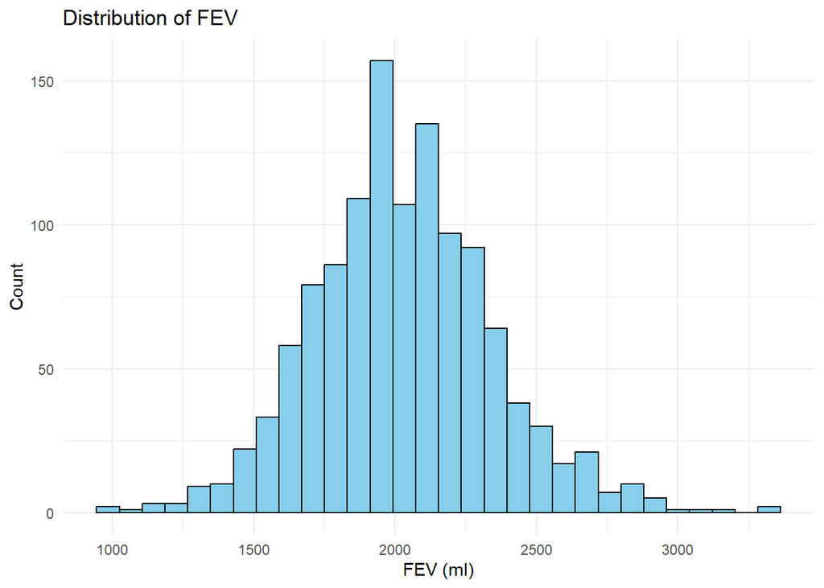

```r
# Histogram of FEV to see if it is normally distributed
ggplot(chs_imputed, aes(x = fev)) +
  geom_histogram(bins = 30, fill = "skyblue", color = "black") +
  theme_minimal() +
  labs(title = "Distribution of FEV", x = "FEV (ml)", y = "Count")
```

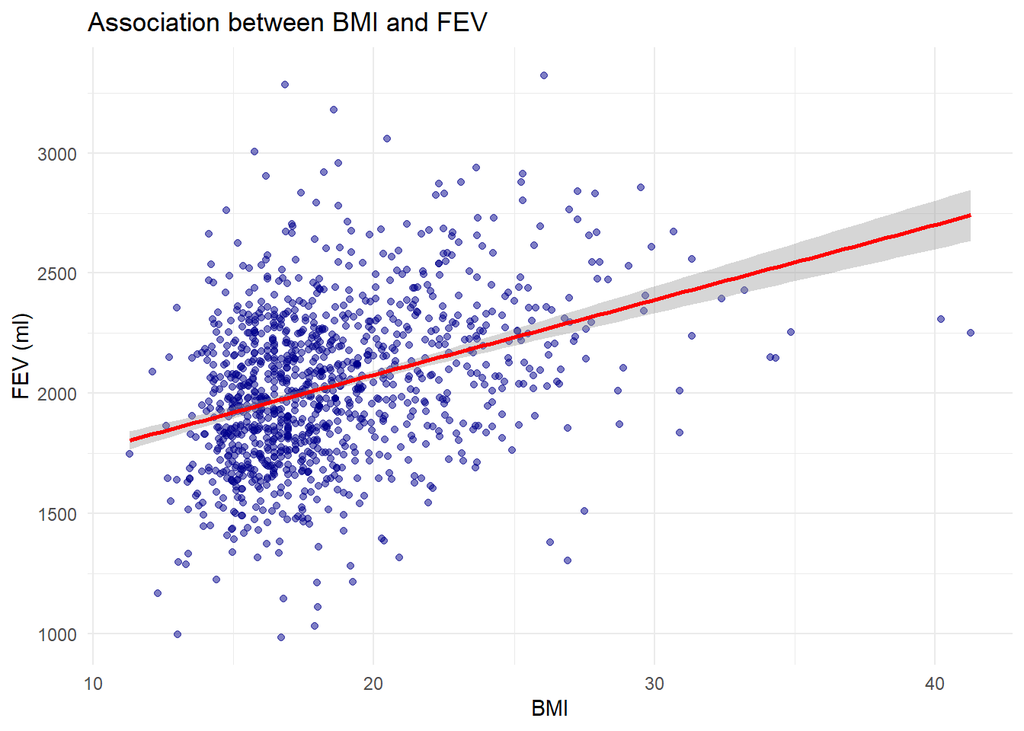

```r
# --- EDA Step 2: Key Question 1 (BMI vs. FEV) ---
# Question: What is the association between BMI and FEV?
ggplot(chs_imputed, aes(x = bmi, y = fev)) +
  geom_point(alpha = 0.5, color = "darkblue") +
  geom_smooth(method = "lm", color = "red") +
  theme_minimal() +
  labs(title = "Association between BMI and FEV",
       x = "BMI", y = "FEV (ml)")
```

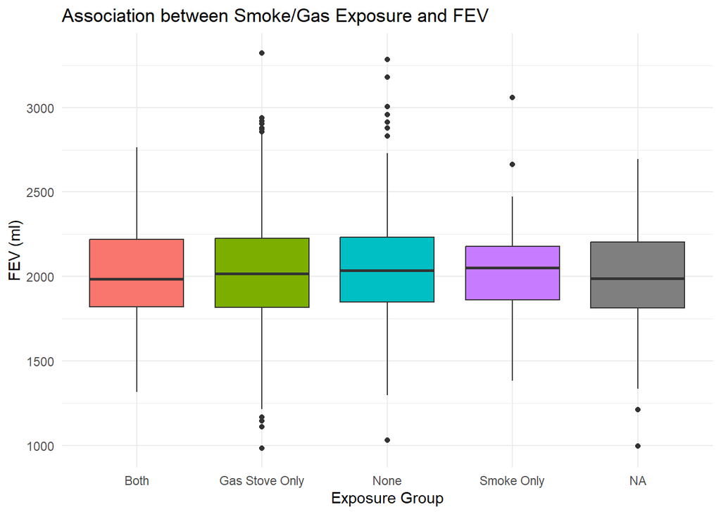

```r
# Calculate correlation coefficient
correlation_bmi <- cor(chs_imputed$bmi, chs_imputed$fev, use = "complete.obs")

# --- EDA Step 3: Key Question 2 (Smoke/Gas vs. FEV) ---
# Question: What is the association between smoke/gas exposure and FEV?
ggplot(chs_imputed, aes(x = smoke_gas_exposure, y = fev, fill = smoke_gas_exposure)) +
  geom_boxplot() +
  theme_minimal() +
  theme(legend.position = "none") +
  labs(title = "Association between Smoke/Gas Exposure and FEV",
       x = "Exposure Group", y = "FEV (ml)")
```

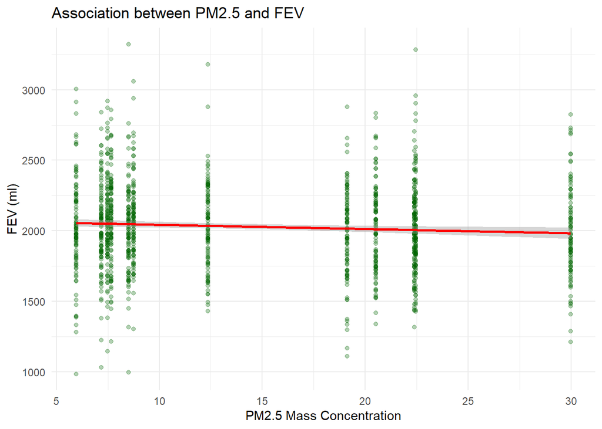

```r
# --- EDA Step 4: Key Question 3 (PM2.5 vs. FEV) ---
# Question: What is the association between PM2.5 exposure and FEV?
ggplot(chs_imputed, aes(x = pm25_mass, y = fev)) +
  geom_point(alpha = 0.3, color = "darkgreen") +
  geom_smooth(method = "lm", color = "red") +
  theme_minimal() +
  labs(title = "Association between PM2.5 and FEV",
       x = "PM2.5 Mass Concentration", y = "FEV (ml)")
```

## Visualization (30 points)

Create the following figures and interpret them. Be sure to include easily understandable axes, titles, and legends.

1. Facet plot showing scatterplots with regression lines of BMI vs FEV by “townname”.

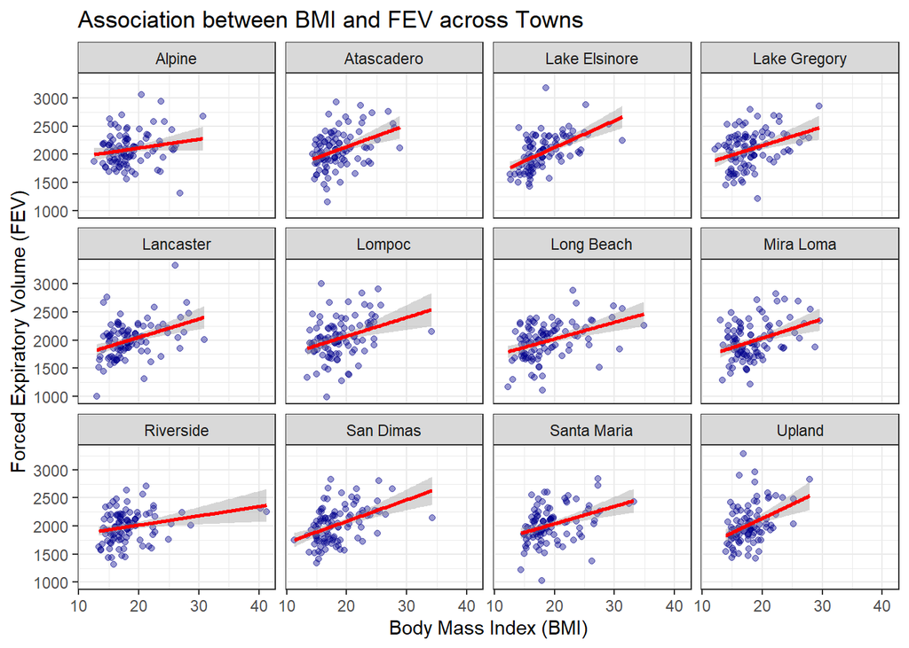

```r
library(leaflet)

# 1. Facet Plot of BMI vs FEV
ggplot(chs_imputed, aes(x = bmi, y = fev)) +
  geom_point(alpha = 0.4, color = "darkblue") +
  geom_smooth(method = "lm", color = "red") +
  facet_wrap(~townname) +
  labs(
    title = "Association between BMI and FEV across Towns",
    x = "Body Mass Index (BMI)",
    y = "Forced Expiratory Volume (FEV)"
  ) +
  theme_bw()
```

Interpret: There is a consistent positive correlation between BMI and FEV across all 12 towns.

2. Stacked histograms of FEV by BMI category and FEV by smoke/gas exposure. Use different color schemes than the ggplot default.

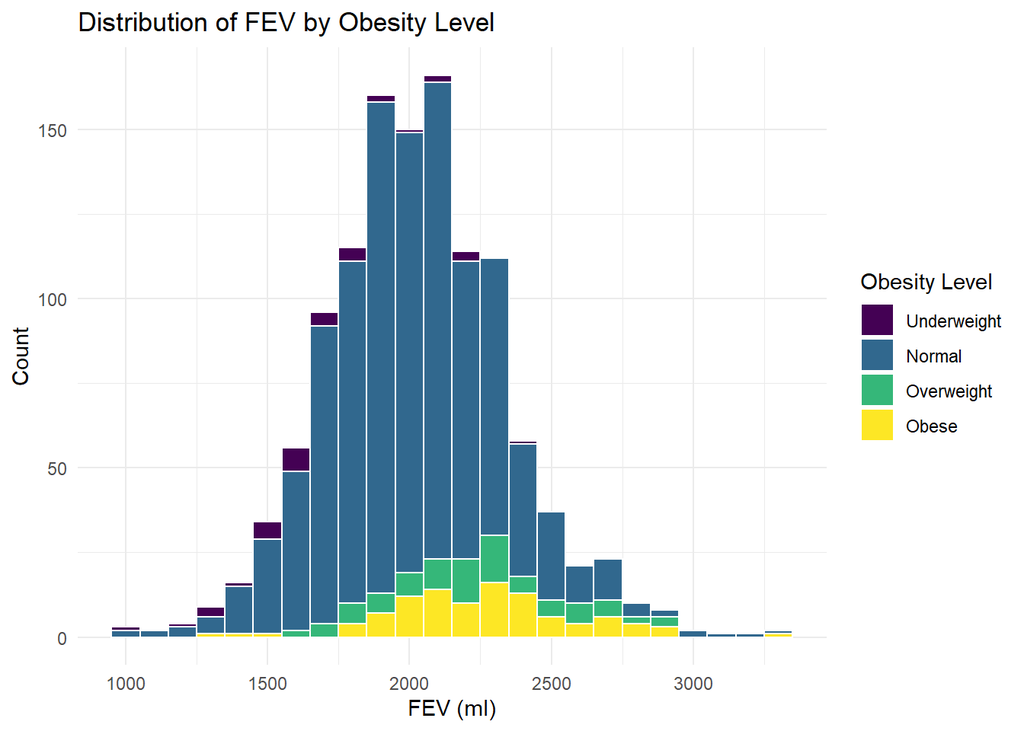

```r
# 2a. FEV by Obesity Level
ggplot(chs_imputed, aes(x = fev, fill = obesity_level)) +
  geom_histogram(binwidth = 100, color = "white") +
  scale_fill_viridis_d(option = "D") +
  labs(
    title = "Distribution of FEV by Obesity Level",
    x = "FEV (ml)",
    y = "Count",
    fill = "Obesity Level"
  ) +
  theme_minimal()
```

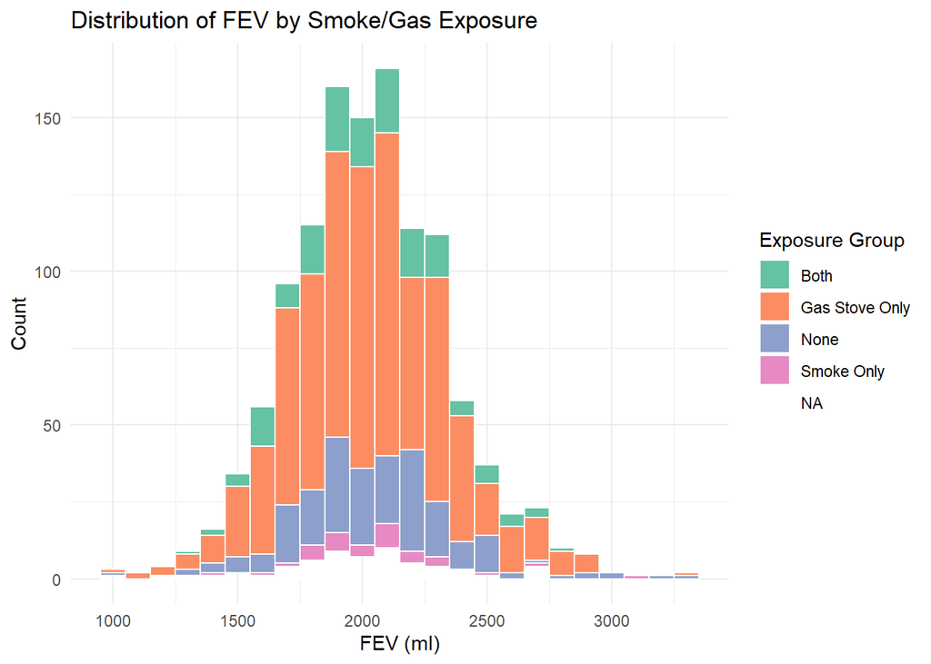

```r
# 2b. FEV by Smoke/Gas Exposure
ggplot(chs_imputed, aes(x = fev, fill = smoke_gas_exposure)) +
  geom_histogram(binwidth = 100, color = "white") +
  scale_fill_brewer(palette = "Set2") +
  labs(
    title = "Distribution of FEV by Smoke/Gas Exposure",
    x = "FEV (ml)",
    y = "Count",
    fill = "Exposure Group"
  ) +
  theme_minimal()
```

Interpret: These two figures suggest that smoke/gas exposure does not have as strong or obvious a correlation with FEV as BMI does.

3. Barchart of BMI by smoke/gas exposure.

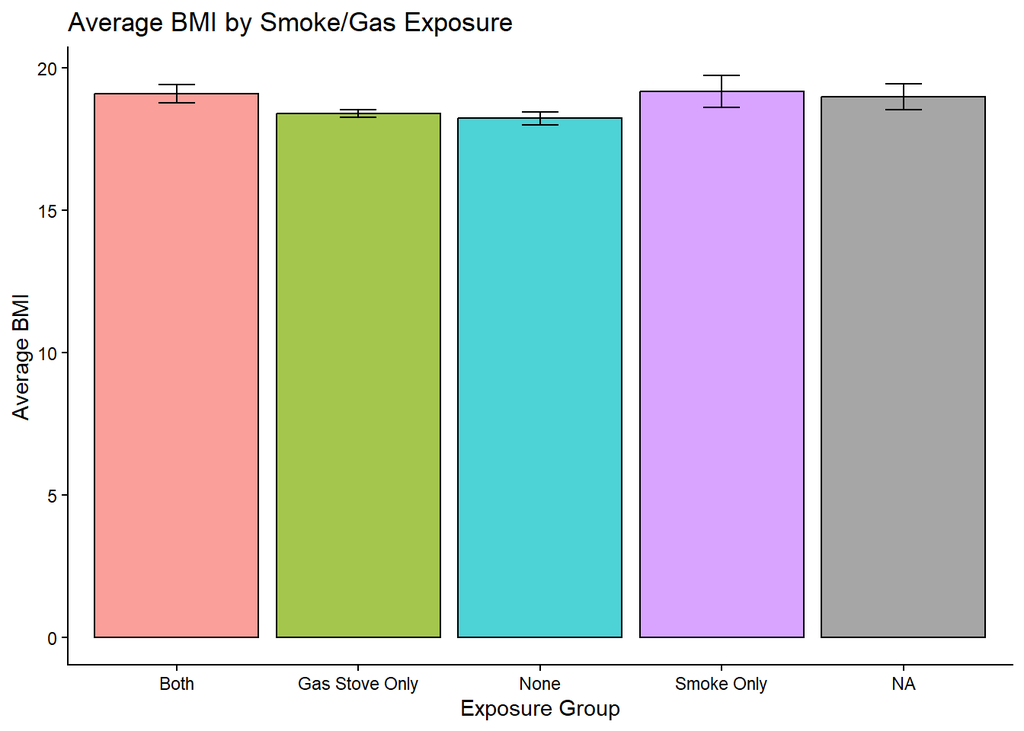

```r
ggplot(chs_imputed, aes(x = smoke_gas_exposure, y = bmi, fill = smoke_gas_exposure)) +
  stat_summary(fun = "mean", geom = "bar", color = "black", alpha = 0.7) +
  stat_summary(fun.data = mean_se, geom = "errorbar", width = 0.2) +
  labs(
    title = "Average BMI by Smoke/Gas Exposure",
    x = "Exposure Group",
    y = "Average BMI"
  ) +
  theme_classic() +
  theme(legend.position = "none")
```

Interpret: The average BMI is consistent across all four exposure categories. Because the average BMI is essentially the same for all groups, BMI is likely not a confounding variable in the relationship between exposure and FEV.

4. Statistical summary graphs of FEV by BMI and FEV by smoke/gas exposure category.

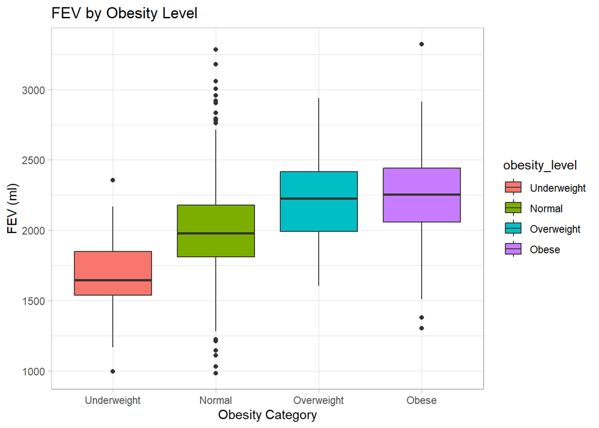

```r
# 4a. FEV by BMI Category
ggplot(chs_imputed, aes(x = obesity_level, y = fev, fill = obesity_level)) +
  geom_boxplot() +
  labs(
    title = "FEV by Obesity Level",
    x = "Obesity Category",
    y = "FEV (ml)"
  ) +
  theme_light()
```

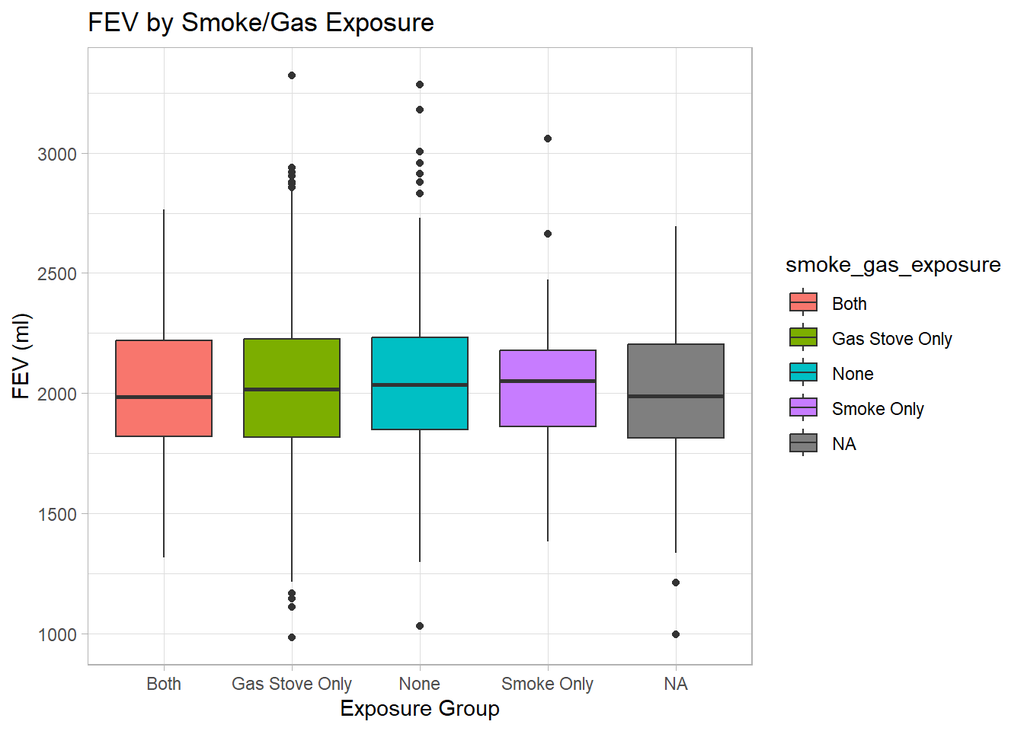

```r
# 4b. FEV by Smoke/Gas Exposure
ggplot(chs_imputed, aes(x = smoke_gas_exposure, y = fev, fill = smoke_gas_exposure)) +
  geom_boxplot() +
  labs(
    title = "FEV by Smoke/Gas Exposure",
    x = "Exposure Group",
    y = "FEV (ml)"
  ) +
  theme_light()
```

Interpret: There is a distinct, stepwise increase in lung function (FEV) as obesity level increases. Smoke and gas exposure do not show a dramatic impact on FEV.

5. A leaflet map showing the concentrations of PM2.5 mass in each of the CHS communities.

```r
# 5. Leaflet Map
library(dplyr)
library(leaflet)

# aggregate by town to get one row per town, with its Lat/Lon and PM2.5
town_data <- chs_imputed %>%
  group_by(townname) %>%
  summarise(
    lat = first(lat),
    lon = first(lon),
    pm25 = first(pm25_mass)
  )

# Create color palette for PM2.5
pal <- colorNumeric(palette = "YlOrRd", domain = town_data$pm25)

leaflet(town_data) %>%
  addProviderTiles(providers$CartoDB.Positron) %>%
  addCircleMarkers(
    lng = ~lon,
    lat = ~lat,
    color = ~pal(pm25),
    fillOpacity = 0.8,
    radius = 8,
    popup = ~paste("Town:", townname, "<br>", "PM2.5:", pm25)
  ) %>%
  addLegend("bottomright", pal = pal, values = ~pm25,
            title = "PM2.5 Mass", opacity = 1)
```

[interactive chart not shown]

Interpret: The map reveals a clear spatial gradient where PM2.5 concentrations increase as you move inland from the coast.

6. Choose a visualization to examine whether PM2.5 mass is associated with FEV.

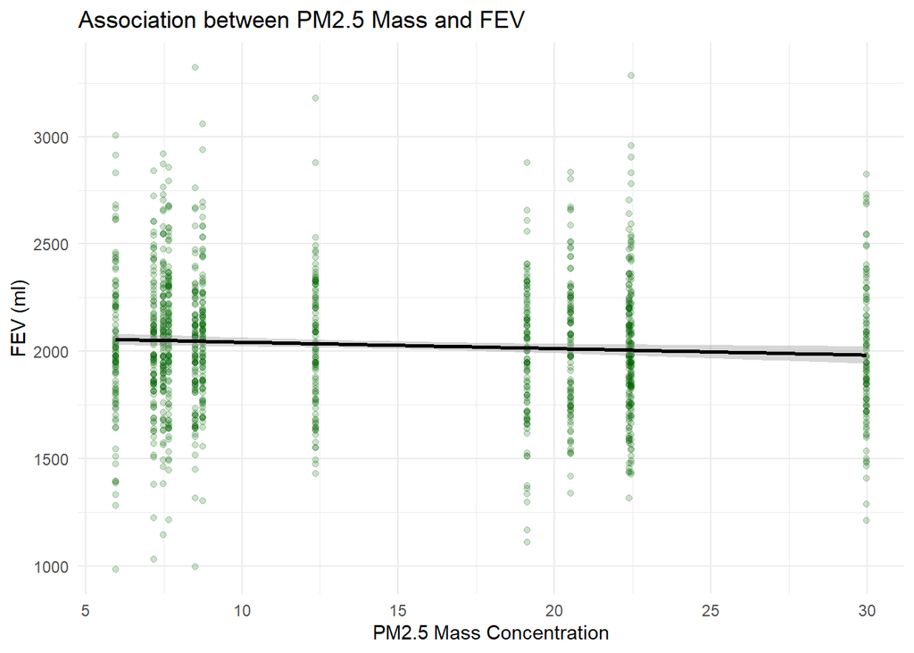

```r
ggplot(chs_imputed, aes(x = pm25_mass, y = fev)) +
  geom_point(alpha = 0.2, color = "darkgreen") +
  geom_smooth(method = "lm", color = "black") +
  labs(
    title = "Association between PM2.5 Mass and FEV",
    x = "PM2.5 Mass Concentration",
    y = "FEV (ml)"
  ) +
  theme_minimal()
```

Interpret: This figure suggests that higher PM2.5 concentrations are associated with slightly lower lung function (FEV), but the association is relatively weak.